# News Headlines Dataset For Sarcasm Detection

• **DOMAIN**: Social media analytics

• **Dataset**: Dataset : [News Headlines Dataset For Sarcasm Detection](https://github.com/Jayabharathi-Hari-Vijayakumar/UTAustin_PGP_Datasets/blob/main/Sarcasm_Headlines_Dataset/Sarcasm_Headlines_Dataset.json) .

• **CONTEXT**: Past studies in Sarcasm Detection mostly make use of Twitter datasets collected using hashtag based supervision but such datasets are noisy in terms of labels and language. Furthermore, many tweets are replies to other tweets and detecting sarcasm in these requires the availability of contextual tweets.In this hands-on project, the goal is to build a model to detect whether a sentence is sarcastic or not, using Bidirectional LSTMs.

• **DATA DESCRIPTION:** The dataset is collected from two news websites, theonion.com and huffingtonpost.com. This new dataset has the following advantages over the existing Twitter datasets: Since news headlines are written by professionals in a formal manner, there are no spelling mistakes and informal usage. This reduces the sparsity and also increases the chance of finding pre-trained embeddings. Furthermore, since the sole purpose of TheOnion is to publish sarcastic news, we get high-quality labels with much less noise as compared to Twitter datasets. Unlike tweets that reply to other tweets, the news headlines obtained are self-contained. This would help us in teasing apart the real sarcastic elements

Content: Each record consists of three attributes: is_sarcastic: 1 if the record is sarcastic otherwise 0 headline: the headline of the news article

**article_link**: link to the original news article. Useful in collecting supplementary data Reference: https://github.com/rishabhmisra/News-Headlines-Dataset-For-Sarcasm-Detection

```python
# Mounting Google Drive
from google.colab import drive
drive.mount('/content/drive')
```

```python
#importing the packages.
import numpy as np
import pandas as pd
import seaborn as sns
import scipy.stats as stats
import matplotlib.pyplot as plt
from tensorflow import keras
%matplotlib inline

import random, re
import nltk
from nltk.corpus import stopwords
import string
nltk.download('stopwords')
from bs4 import BeautifulSoup
from wordcloud import WordCloud
from nltk.stem import WordNetLemmatizer

# Models
from tensorflow.keras.layers import Dense, LSTM, Embedding, Dropout, Flatten, Bidirectional, GlobalMaxPool1D
from tensorflow.keras.callbacks import EarlyStopping, ModelCheckpoint, ReduceLROnPlateau, TensorBoard
from tensorflow.keras.preprocessing.sequence import pad_sequences
from tensorflow.keras.preprocessing.text import Tokenizer
from tensorflow.keras.models import Model, Sequential
from tensorflow.keras.initializers import Constant

from sklearn.metrics import classification_report, confusion_matrix
from sklearn.model_selection import train_test_split
import re
import os
import tensorflow as tf
!pip install text-preprocessing
from text_preprocessing import *
# Set random state
random_state = 42
np.random.seed(random_state)
tf.random.set_seed(random_state)

tf.__version__
```

```
'2.14.0'
```

```python
#Set your project path
project_path =  '/content/drive/MyDrive/GL_files/GL_Dataset/'
DF = pd.read_json(os.path.join(project_path,'Sarcasm_Headlines_Dataset.json'),lines=True)
##DF = pd.read_json('/content/drive/MyDrive/GL_files/GL_Dataset/Sarcasm_Headlines_Dataset.json',lines = True)
```

```python
#Printing the dataset
DF
```

|  | article_link | headline | is_sarcastic |
| --- | --- | --- | --- |
| 0 | https://www.huffingtonpost.com/entry/versace-b... | former versace store clerk sues over secret 'b... | 0 |
| 1 | https://www.huffingtonpost.com/entry/roseanne-... | the 'roseanne' revival catches up to our thorn... | 0 |
| 2 | https://local.theonion.com/mom-starting-to-fea... | mom starting to fear son's web series closest ... | 1 |
| 3 | https://politics.theonion.com/boehner-just-wan... | boehner just wants wife to listen, not come up... | 1 |
| 4 | https://www.huffingtonpost.com/entry/jk-rowlin... | j.k. rowling wishes snape happy birthday in th... | 0 |
| ... | ... | ... | ... |
| 26704 | https://www.huffingtonpost.com/entry/american-... | american politics in moral free-fall | 0 |
| 26705 | https://www.huffingtonpost.com/entry/americas-... | america's best 20 hikes | 0 |
| 26706 | https://www.huffingtonpost.com/entry/reparatio... | reparations and obama | 0 |
| 26707 | https://www.huffingtonpost.com/entry/israeli-b... | israeli ban targeting boycott supporters raise... | 0 |
| 26708 | https://www.huffingtonpost.com/entry/gourmet-g... | gourmet gifts for the foodie 2014 | 0 |

26709 rows × 3 columns

```python
DF.info()
```

```
<class 'pandas.core.frame.DataFrame'>
RangeIndex: 26709 entries, 0 to 26708
Data columns (total 3 columns):
 #   Column        Non-Null Count  Dtype
---  ------        --------------  -----
 0   article_link  26709 non-null  object
 1   headline      26709 non-null  object
 2   is_sarcastic  26709 non-null  int64
dtypes: int64(1), object(2)
memory usage: 626.1+ KB
```

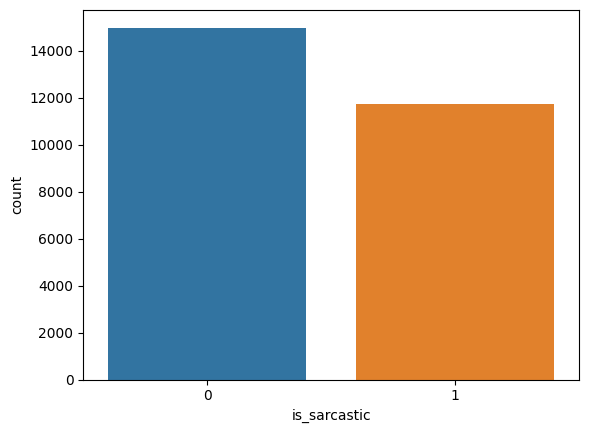

```python
#Visualizing the stats of predicted data
sns.countplot(x='is_sarcastic',data=DF)
```

```python
print('--'*50); print('Value Counts for `is_sarcastic` label'); print('--'*50)
print(f'Is Sarcastic count: {DF[DF.is_sarcastic == 1].shape[0]} i.e. {round(DF[DF.is_sarcastic == 1].shape[0]/DF.shape[0]*100, 0)}%')
print(f'Isn\'t Sarcastic count: {DF[DF.is_sarcastic == 0].shape[0]} i.e. {round(DF[DF.is_sarcastic == 0].shape[0]/DF.shape[0]*100, 0)}%')
print('--'*50)
```

```
----------------------------------------------------------------------------------------------------
Value Counts for `is_sarcastic` label
----------------------------------------------------------------------------------------------------
Is Sarcastic count: 11724 i.e. 44.0%
Isn't Sarcastic count: 14985 i.e. 56.0%
----------------------------------------------------------------------------------------------------
```

```python
print('Analysis of `is_sarcastic` label by news website'); print('--'*50)

hf = DF[DF['article_link'].str.contains('huffingtonpost.com')].shape[0]
op = DF[DF['article_link'].str.contains('theonion.com')].shape[0]

is_sarcastic_hf = DF.loc[(DF['article_link'].str.contains('huffingtonpost.com')) & (DF['is_sarcastic'] == 1)].shape[0]
not_sarcastic_hf = DF.loc[(DF['article_link'].str.contains('huffingtonpost.com')) & (DF['is_sarcastic'] == 0)].shape[0]

is_sarcastic_op = DF.loc[(DF['article_link'].str.contains('theonion.com')) & (DF['is_sarcastic'] == 1)].shape[0]
not_sarcastic_op = DF.loc[(DF['article_link'].str.contains('theonion.com')) & (DF['is_sarcastic'] == 0)].shape[0]

display(pd.DataFrame([[is_sarcastic_hf, is_sarcastic_op], [not_sarcastic_hf, not_sarcastic_op]],
                     columns = ['huffingtonpost', 'theonion'], index = ['Sarcastic', 'Non-sarcastic']))
print('--'*50)
```

```
Analysis of `is_sarcastic` label by news website
----------------------------------------------------------------------------------------------------
```

|  | huffingtonpost | theonion |
| --- | --- | --- |
| Sarcastic | 0 | 11724 |
| Non-sarcastic | 14985 | 1 |

```
------------------------------------------------------------
Checking 5 random headlines and labels from the data where the length of headline is > 100
------------------------------------------------------------
Headline: 'this women's strike won't accomplish anything,' reports man who will boycott upcoming 'avengers' movie
label: 1

Headline: bernie sanders asks trump's education nominee if she's only getting the job because she's a billionaire
label: 0

Headline: study finds controlled washington, d.c. wildfires crucial for restoring healthy political environment
label: 1

Headline: trump's prefrontal cortex admits it can't possibly filter all impulsive comments coming from rest of brain
label: 1

Headline: motion picture academy releases complete list of films that can be enjoyed without supporting sexual predator
label: 1

------------------------------------------------------------
Distributon of label where the length of headline is > 100
------------------------------------------------------------
```

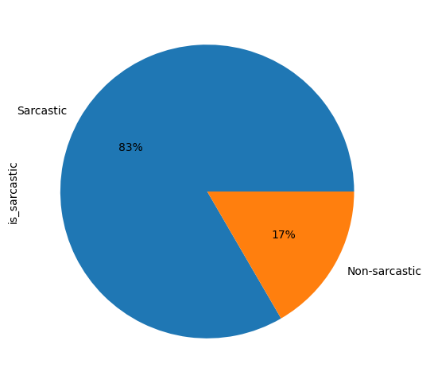

```python
# Checking 5 random headlines and labels from the data where the length of headline is > 100
print('--'*30); print('Checking 5 random headlines and labels from the data where the length of headline is > 100'); print('--'*30)
indexes = list(DF.loc[DF['headline'].str.len() > 100, 'headline'].index)
rands = random.sample(indexes, 5)
headlines, labels = list(DF.loc[rands, 'headline']), list(DF.loc[rands, 'is_sarcastic'])

_ = [print(f'Headline: {head}\nlabel: {label}\n') for head, label in zip(headlines, labels)]

print('--'*30); print('Distributon of label where the length of headline is > 100'); print('--'*30)
_ = DF.loc[indexes, 'is_sarcastic'].value_counts().plot(kind = 'pie', autopct = '%.0f%%', labels = ['Sarcastic', 'Non-sarcastic'], figsize = (10, 6))
```

```python
# Define regex patterns for URL patterns to remove
url_patterns = [
    r"http[s]?://\S+",
    r"www\.\S+",
    r"\S+\.com",
    r"\S+\.org",
    # Will add more specific extensions if needed
]

# Combine the regex patterns into a single pattern
combined_pattern = "|".join(url_patterns)

# Remove URLs and specific patterns from the 'text' column
DF['headline'] = DF['headline'].apply(lambda x: re.sub(combined_pattern, '', x))
```

```python
# Convert text to lowercase and remove non-alphabetic characters
DF['headline'] = DF['headline'].str.lower()
DF['headline'] = DF['headline'].apply(lambda x: re.sub("[^a-z\s]", " ", x))

# Remove extra whitespaces
DF['headline'] = DF['headline'].str.replace('\s+', ' ')
```

```python
stop = set(stopwords.words('english'))
punctuation = list(string.punctuation)
stop.update(punctuation)
def strip_html(text):
    soup = BeautifulSoup(text, "html.parser")
    return soup.get_text()

#Removing the square brackets
def remove_between_square_brackets(text):
    return re.sub('\[[^]]*\]', '', text)
# Removing URL's
def remove_between_square_brackets(text):
    return re.sub(r'http\S+', '', text)
#Removing the stopwords from text
def remove_stopwords(text):
    final_text = []
    for i in text.split():
        if i.strip().lower() not in stop:
            final_text.append(i.strip())
    return " ".join(final_text)
# Create a WordNetLemmatizer instance
lemmatizer = WordNetLemmatizer()

# Define a function to lemmatize a string
def lemmatize_text(text):
    words = text.split()  # Split the text into words
    lemmatized_words = [lemmatizer.lemmatize(word) for word in words]
    return ' '.join(lemmatized_words)  # Join the lemmatized words back into a string

#Removing the noisy text
def denoise_text(text):
    text = strip_html(text)
    text = remove_between_square_brackets(text)
    text = remove_stopwords(text)
    text = lemmatize_text(text)

    return text
DF['headline']=DF['headline'].apply(denoise_text)
```

```python
DF['headline']
```

```
0        former versace store clerk sue secret black co...
1        roseanne revival catch thorny political mood b...
2        mom starting fear son web series closest thing...
3        boehner want wife listen come alternative debt...
4        j k rowling wish snape happy birthday magical way
                               ...
26704                    american politics moral free fall
26705                                    america best hike
26706                                     reparation obama
26707    israeli ban targeting boycott supporter raise ...
26708                                  gourmet gift foodie
Name: headline, Length: 26709, dtype: object
```

```python
DF['headline']
```

```
0        former versace store clerk sue secret black co...
1        roseanne revival catch thorny political mood b...
2        mom starting fear son web series closest thing...
3        boehner want wife listen come alternative debt...
4        j k rowling wish snape happy birthday magical way
                               ...
26704                    american politics moral free fall
26705                                    america best hike
26706                                     reparation obama
26707    israeli ban targeting boycott supporter raise ...
26708                                  gourmet gift foodie
Name: headline, Length: 26709, dtype: object
```

# Word Cloud of headline

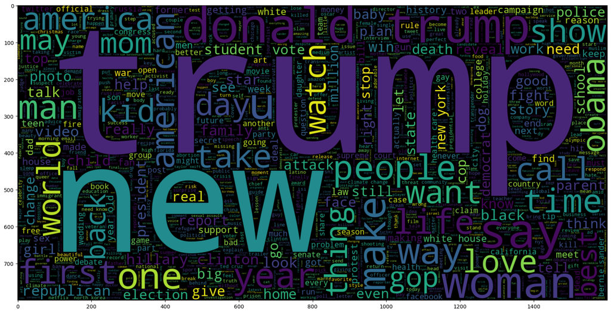

```python
plt.figure(figsize = (20,20))
wc = WordCloud(max_words = 2000 , width = 1600 , height = 800).generate(" ".join(DF[DF.is_sarcastic == 0].headline))
plt.imshow(wc , interpolation = 'bilinear')
```

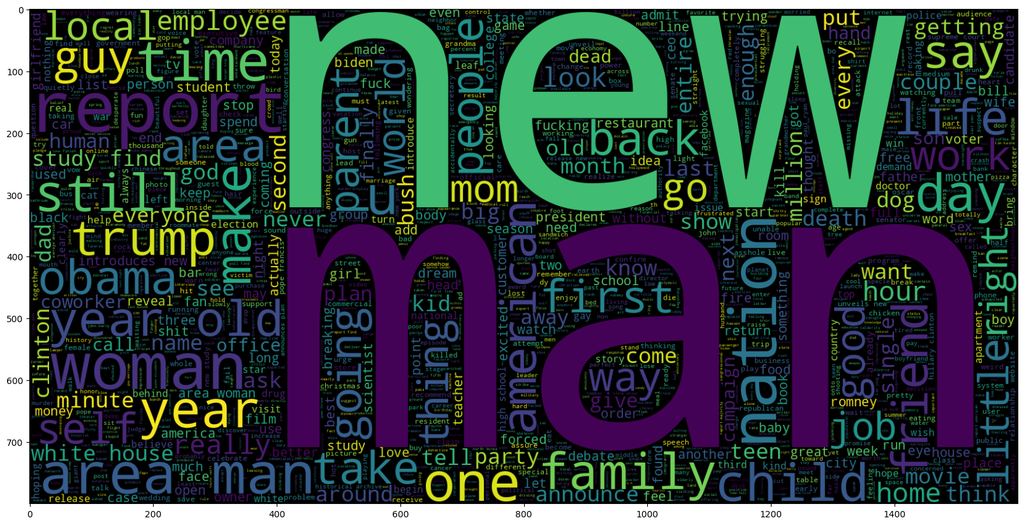

```python
plt.figure(figsize = (20,20)) # Text that is Sarcastic
wc = WordCloud(max_words = 2000 , width = 1600 , height = 800).generate(" ".join(DF[DF.is_sarcastic == 1].headline))
plt.imshow(wc , interpolation = 'bilinear')
```

# **Visualization of characters in text**

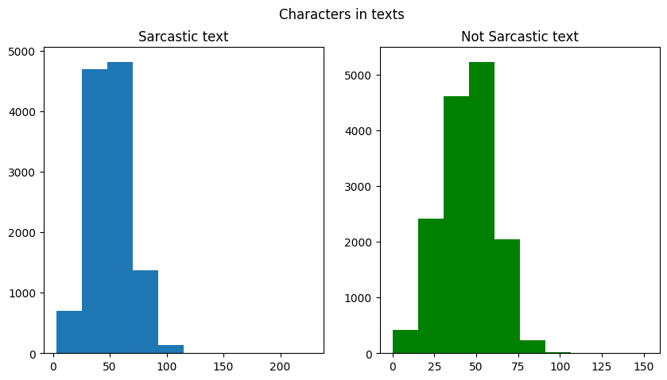

```python
fig,(ax1,ax2) = plt.subplots(1,2,figsize=(10,5))
text_len=DF[DF['is_sarcastic']==1]['headline'].str.len()
ax1.hist(text_len)
ax1.set_title('Sarcastic text')
text_len=DF[DF['is_sarcastic']==0]['headline'].str.len()
ax2.hist(text_len, color='green')
ax2.set_title('Not Sarcastic text')
fig.suptitle('Characters in texts')
plt.show()
```

# **Visualization of words in texts**

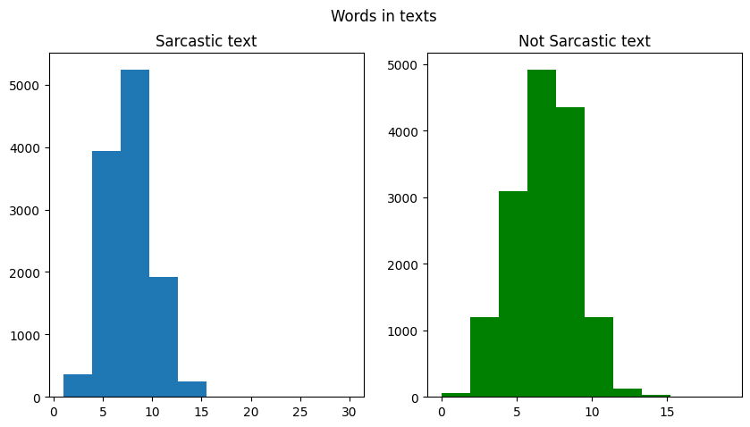

```python
fig,(ax1,ax2)=plt.subplots(1,2,figsize=(10,5))
text_len=DF[DF['is_sarcastic']==1]['headline'].str.split().map(lambda x: len(x))
ax1.hist(text_len)
ax1.set_title('Sarcastic text')
text_len=DF[DF['is_sarcastic']==0]['headline'].str.split().map(lambda x: len(x))
ax2.hist(text_len,color='green')
ax2.set_title('Not Sarcastic text')
fig.suptitle('Words in texts')
plt.show()
```